패키지 준비

```r
library(xlsx)
library(rJava)
library(dplyr)
```

```r
library(stringr)
library(ggplot2)
library(pgirmess)
```

1. 데이터 준비 1-1-1. 지하상가 임대정보 데이터

```r
subway <- read.csv("C:/Users/Master/Desktop/R/서울교통공사_지하상가임대정보_20200831.csv", header=T)
View(subway)
dim(subway)
```

```
## [1] 1681   11
```

```r
str(subway)
```

```
## 'data.frame':    1681 obs. of  11 variables:
##  $ NO      : int  1 2 3 4 5 6 7 8 9 10 ...
##  $ 상가유형: chr  "개별(일반)" "소송상가" "네트워크" "개별(일반)" ...
##  $ 호선    : chr  "1호선" "1호선" "1호선" "1호선" ...
##  $ 역명    : chr  "서울역_1" "서울역_1" "서울역_1" "시청_1" ...
##  $ 상가번호: chr  "150-107" "150-109" "150-110" "151-101" ...
##  $ 면적... : num  33 12 41.3 29.7 57.6 ...
##  $ 영업업종: chr  "사무실" "커피" "화장품" "의류" ...
##  $ 보호업종: chr  "" "" "" "" ...
##  $ 계약시작: chr  "2019-05-08" "2012-05-21" "2015-09-05" "2017-04-04" ...
##  $ 계약종료: chr  "2024-06-06" "2017-07-10" "2020-11-03" "2022-05-03" ...
##  $ 임대료  : int  527100 5178550 17414416 3858954 1858300 NA NA 1801800 NA 20734494 ...
```

```r
table(subway$"상가유형")
```

```
##
##         GS 개별(대형) 개별(일반)       공실   네트워크       복합   소송상가
##        192         23        522        350        313        207         74
```

```r
table(subway$"영업업종")
```

```
##
##                                          H&B드럭스토어 등
##                          359                            1
##                     가공식품                     가구판매
##                            1                            1
##                         가방                     간이음식
##                            1                            9
##                     건강식품          고속터미널 복합상가
##                            7                            9
##                         공실                     공익상가
##                          195                            3
##                         과일                         구두
##                            1                            1
##                     귀금속류                     규방공예
##                            2                            1
##                       금융업                           꽃
##                            3                           28
##                         낙찰                     낚시용품
##                            2                            1
##                     네일아트                       농산물
##                            1                            9
##                       다이소               디저트(완제품)
##                            1                            2
##                           떡                         만두
##                            6                            1
## 멀티편의공간(다이소 및 카페)                       메디컬
##                            8                            2
##                         명함                     문화복지
##                            1                           12
##               물품보관서비스                     베이커리
##                            2                            7
##                       보청기                         분식
##                            1                           21
##                       사무실                     생활용품
##                           32                           10
##                         서점                       세탁방
##                           11                            1
##                         속옷                       수공업
##                            1                            1
##                     수입과자                 스포츠용품점
```

[output cut: 32 more lines]

```
##                            7                            1
##                       편의점                     푸른마을
##                          189                            4
##                   한복대여점                 한지공예공방
##                            1                            1
##                       핸드폰                         헤어
##                           17                            1
##                         헬스                     혈액센터
##                            5                            1
##                   홍보/ 전시                         화실
##                            1                            1
##                       화장품                         화훼
##                           62                            4
##                     휴게음식
##                            4
```

```r
table(subway$"호선")
```

```
##
## 1호선 2호선 3호선 4호선 5호선 6호선 7호선 8호선
##    22   296   180   155   300   226   435    67
```

```r
table(subway$"역명")
```

```
##
##           가락시장_3           가락시장_8     가산디지털단지_7
##                    1                    7                    5
##                 강남             강남구청                 강동
##                    6                   21                   10
##             강동구청                 강변                 개롱
##                    4                    2                    1
##               개화산                 거여           건대입구_2
##                    1                    1                   11
##           건대입구_7               경복궁             경찰병원
##                    8                    1                    2
##                 고덕               고려대         고속터미널_3
##                    2                    5                   41
##         고속터미널_7               공덕_5               공덕_6
##                   19                   29                   15
##                 공릉               광나루           광명사거리
##                    6                    4                    9
##               광화문               광흥창               교대_2
##                    5                    6                    8
##               교대_3       구로디지털단지                 구산
##                   11                    4                    5
##                 구의               군자_5               군자_7
##                    5                    4                   14
##               굴포천             굽은다리                 금호
##                    1                    5                    5
##                 길동                 길음           김포공항_5
##                    1                    2                   13
##             까치산_5               까치울               낙성대
##                    9                    1                    4
##               남구로                 남성         남한산성입구
##                    6                    5                    6
##                 내방               노원_4               노원_7
##                    6                    2                   22
##                 녹번               녹사평                 논현
##                    5                    1                   16
##           단대오거리               답십리               당고개
##                    5                    7                    7
##                 당산               대림_2               대림_7
##                    6                    9                   12
##                 대청                 대흥                 도곡
```

[output cut: 114 more lines]

```
##                   17                    1                    5
##             충정로_2             충정로_5           태릉입구_6
##                    3                    6                   10
##           태릉입구_7                 하계                 학동
##                   10                   10                   15
##               한강진           한성대입구               한양대
##                    4                    1                    4
##               합정_2               합정_6                 행당
##                   14                   16                    4
##                 혜화             홍대입구                 홍제
##                    2                    8                    9
##                 화곡               화랑대                 회현
##                    7                    7                    3
##           효창공원앞
##                    6
```

1-1-2. 지하상가 임대정보 데이터 전처리

```r
subway <- rename(subway, "면적"= 면적...)
subway_de <- subset(subway, select=-c(NO, 보호업종, 상가번호, 계약시작, 계약종료))
subway_ms <- subway %>% filter(상가유형 != "공실" & 영업업종 != "공실" & !is.na("면적") & 임대료 != 0 & 영업업종 != "") %>% group_by(역명) %>% summarise(mean_i=mean(임대료), sum_i=sum(임대료))
```

1-2-1. 지하철 이용객 승하차 인원 데이터

```r
passenger1 <-read.xlsx("C:/Users/Master/Desktop/R/2020년 1월_9월 역별 수송수입실적(홈페이지).xlsx", sheetIndex=3, encoding = "UTF-8", startRow=47)

str(passenger1)
```

```
## 'data.frame':    290 obs. of  17 variables:
##  $ 소...계.1.8호선.: chr  "1\n호\n선" NA NA NA ...
##  $ NA.             : num  150 151 152 153 154 155 156 157 158 159 ...
##  $ NA..1           : chr  "서울역_1" "시청_1" "종각" "종로3가_1" ...
##  $ X1941814283     : num  19271145 9305144 16183400 12199520 10298572 ...
##  $ X8005099        : num  78980 38136 66325 49998 42207 ...
##  $ X271351777      : num  3198290 1477362 2462560 1935106 1527217 ...
##  $ X223795684      : num  2271168 1149641 1945843 1421415 1149021 ...
##  $ X185092194      : num  1601396 888317 1475933 1095035 947157 ...
##  $ X195853780      : num  1803550 874072 1586710 1224282 1040487 ...
##  $ X214845496      : num  2112629 962697 1745454 1374997 1182917 ...
##  $ X224400508      : num  2201148 1042088 1892509 1360814 1182427 ...
##  $ X239247725      : num  2391615 1134098 2069902 1523797 1263489 ...
##  $ X199989833      : num  1986290 922958 1626359 1212158 1017196 ...
##  $ X187237286      : num  1705059 853911 1378130 1051916 988661 ...
##  $ X0              : num  0 0 0 0 0 0 0 0 0 0 ...
##  $ X0.1            : num  0 0 0 0 0 0 0 0 0 0 ...
##  $ X0.2            : num  0 0 0 0 0 0 0 0 0 0 ...
```

```r
View(passenger1)
```

1-2-2. 지하철 이용객 승하차 인원 데이터 전처리

```r
passenger1 <- passenger1[-c(278:290),]
passenger <- subset(passenger1, select=-c(NA., X0, X0.1, X0.2))

View(passenger)
passenger <- rename(passenger, "호선"=소...계.1.8호선., "역명"=NA..1,
                    "합계"=X1941814283, "일평균"=X8005099, "1월"=X271351777, "2월"=X223795684,"3월"=X185092194,"4월"=X195853780,"5월"=X214845496,
                    "6월"=X224400508, "7월"=X239247725, "8월"=X199989833, "9월"=X187237286)
passenger$호선[c(1:10)] <- "1호선"
passenger$호선[c(11:60)] <- "2호선"
passenger$호선[c(61:93)] <- "3호선"
passenger$호선[c(94:119)] <- "4호선"
passenger$호선[c(120:172)] <- "5호선"
passenger$호선[c(173:209)] <- "6호선"
passenger$호선[c(210:260)] <- "7호선"
passenger$호선[c(261:277)] <- "8호선"
```

1-3-1. 혼잡도 데이터

```r
congestion1 <- read.csv("c:/Users/Master/Desktop/R/서울교통공사_혼잡도_20191231.csv", header=T)
View(congestion1)
str(congestion1)
```

```
## 'data.frame':    1668 obs. of  45 variables:
##  $ 조사일자    : chr  "평일" "평일" "평일" "평일" ...
##  $ 호선        : chr  "1호선" "1호선" "1호선" "1호선" ...
##  $ 역번호      : int  150 150 151 151 152 152 153 153 154 154 ...
##  $ 역명        : chr  "서울역_1" "서울역_1" "시청_1" "시청_1" ...
##  $ 구분        : chr  "상선" "하선" "상선" "하선" ...
##  $ 구분.1      : chr  "혼잡도" "혼잡도" "혼잡도" "혼잡도" ...
##  $ X05.30......: num  8.2 11.8 7.7 9.5 6.3 11.1 6.3 12.1 5.6 13.4 ...
##  $ X06.00......: num  12.9 13.5 11.2 11.3 8.1 12.3 8.1 12.2 6.5 17.2 ...
##  $ X06.30......: num  21.5 12.2 19.6 11.6 15.5 12.8 14.4 15.9 12.4 17.1 ...
##  $ X07.00......: num  28.4 17.8 24.4 16.7 16.6 19.3 16.3 23.1 12.4 27.4 ...
##  $ X07.30......: num  46.7 26.4 36.2 23.2 22.7 28.6 22.9 39.9 16.5 45.1 ...
##  $ X08.00......: num  70 34.8 53.7 34.1 34.8 44.2 36.2 59 28.8 70.8 ...
##  $ X08.30......: num  74.5 25.2 51.7 26.4 28.7 41.2 34.8 69.1 23.6 68.2 ...
##  $ X09.00......: num  52.2 21 47.1 21 32.4 26.7 31.1 37.4 21.3 37.2 ...
```

[output cut: 31 more lines]

```r
#혼잡도 100% 혼잡도는 1량당 160명 탑승을 기준으로 합니다.
#80%이하 여유 / 80~130% 보통 /130~150% 주의 /150%이상 혼잡
```

1-3-2. 혼잡도 데이터 전처리

```r
congestion1 <- congestion1[-c(2, 3, 5, 6)]
congestion1[is.na(congestion1)] <-0
congestion <- congestion1 %>% group_by(역명, 조사일자) %>% summarise(mean_5.30=round(mean(X05.30......),2), mean_6.00=round(mean(X06.00......),2), mean_6.30=round(mean(X06.30......),2), mean_7.00=round(mean(X07.00......),2),
                                                         mean_7.30=round(mean(X07.30......),2), mean_8.00=round(mean(X08.00......),2), mean_8.30=round(mean(X08.30......),2), mean_9.00=round(mean(X09.00......),2),
                                                         mean_9.30=round(mean(X09.30......),2), mean_10.00=round(mean(X10.00......),2), mean_10.30=round(mean(X10.30......),2), mean_11.00=round(mean(X11.00......),2),
                                                         mean_11.30=round(mean(X11.30......),2), mean_12.00=round(mean(X12.00......),2), mean_12.30=round(mean(X12.30......),2), mean_13.00=round(mean(X13.00......),2),
                                                         mean_13.30=round(mean(X13.30......),2), mean_14.00=round(mean(X14.00......),2), mean_14.30=round(mean(X14.30......),2), mean_15.00=round(mean(X15.00......),2),
                                                         mean_15.30=round(mean(X15.30......),2), mean_16.00=round(mean(X16.00......),2), mean_16.30=round(mean(X16.30......),2), mean_17.00=round(mean(X17.00......),2),
                                                         mean_17.30=round(mean(X17.30......),2), mean_18.00=round(mean(X18.00......),2), mean_18.30=round(mean(X18.30......),2), mean_19.00=round(mean(X19.00......),2),
                                                         mean_19.30=round(mean(X19.30......),2), mean_20.00=round(mean(X20.00......),2), mean_20.30=round(mean(X20.30......),2), mean_21.00=round(mean(X21.00......),2),
                                                         mean_21.30=round(mean(X21.30......),2), mean_22.00=round(mean(X22.00......),2), mean_22.30=round(mean(X22.30......),2), mean_23.00=round(mean(X23.00......),2),
                                                         mean_23.30=round(mean(X23.30......),2), mean_24.00=round(mean(X24.00......),2), mean_24.30=round(mean(X24.30......),2))
View(congestion)
```

1-4-1. 역사심도 데이터 (정거장 층수를 알아보기 위한)

```r
depth <- read.csv("c:/Users/Master/Desktop/R/서울교통공사_역사심도정보_20200929.csv",header=T)
str(depth)
```

```
## 'data.frame':    278 obs. of  9 variables:
##  $ 호선                                 : int  1 1 1 1 1 1 1 1 1 1 ...
##  $ 정거장명                             : chr  "서울역_1" "시청_1" "종각" "종로3가_1" ...
##  $ 정거장층수                           : chr  "B2" "B2" "B2" "B2" ...
##  $ 형식                                 : chr  "섬식" "상대식" "상대식" "상대식" ...
##  $ ⓐ지반고.해발고도.100.3m.            : num  130 130 129 124 122 ...
##  $ ⓑ레일면고.해발고도.100.3m.          : num  117 119 116 112 109 ...
##  $ 정거장.깊이.선로기준..ⓐ.ⓑ..m.      : num  12.9 11.2 12.5 12.3 12.5 ...
##  $ 정거장.깊이.승강장기준..ⓐ.ⓑ.1.1..m.: num  11.8 10.1 11.4 11.2 11.4 ...
##  $ 비고                                 : chr  "4호선환승" "2호선환승" "" "3호선/5호선환승" ...
```

```r
View(depth)
```

1-4-1. 역사심도 데이터 (정거장 층수를 알아보기 위한) 전처리

```r
depth <- rename(depth, "역명"=정거장명)
depth <- subset(depth, select=-c(비고))
View(depth)
```

1-5-1. 공기질 데이터

```r
air <- read.csv("c:/Users/Master/Desktop/R/서울교통공사_지하역사공기질측정결과_2019.csv",header=T)

View(air)
str(air)
```

```
## 'data.frame':    254 obs. of  6 variables:
##  $ 호선명                         : chr  "1호선" "1호선" "1호선" "1호선" ...
##  $ 역명                           : chr  "서울역_1" "시청_1" "종각" "종로3가_1" ...
##  $ 미세먼지_PM.10.140.....이하.   : num  70.5 54.7 82.9 70.4 70.2 49.4 62.4 75.9 71.3 65.6 ...
##  $ 이산화탄소_CO2..1000.ppm.이하. : int  606 581 471 481 597 624 556 645 533 572 ...
##  $ 포름알데히드_HCHO.100.....이하.: num  4 4.4 11.5 11 5.7 5.4 3.4 3.2 3.7 4.3 ...
##  $ 일산화탄소_CO.9.ppm이하.       : num  0.8 0.7 0.7 1 0.8 1 0.7 0.6 0.8 1.1 ...
```

```r
#SPM.미세먼지 (기준치 140㎍/㎥)
#CO2.이산화탄소 (기준치 1000ppm)
#CO.일산화탄소 (기준치 9ppm)
#HCHO.포름알데히드 (기준치 100ppm)
```

1-5-2. 공기질 데이터 전처리

```r
air[is.na(air)] <-0
air <- rename(air, "호선"=호선명, "SPM"=미세먼지_PM.10.140.....이하.   , "CO2"=이산화탄소_CO2..1000.ppm.이하., "CO"=일산화탄소_CO.9.ppm이하., "HCHO"=포름알데히드_HCHO.100.....이하.)
```

2-1. 상가 유형에 따른 임대료 차이 : 어떤 유형이 가장 많은 또는 적게 임대료를 내는가? / 상가유형은 임대료에 영향을 주는가?

```r
table(subway$상가유형)
```

```
##
##         GS 개별(대형) 개별(일반)       공실   네트워크       복합   소송상가
##        192         23        522        350        313        207         74
```

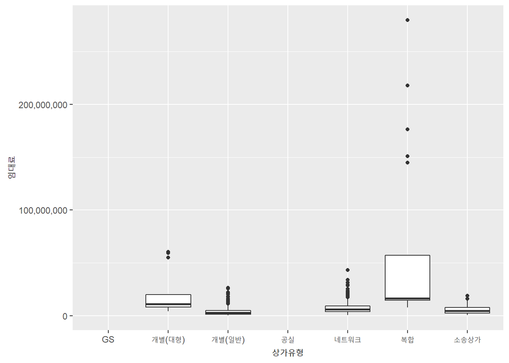

```r
ggplot(data=subway, aes(x=상가유형,y=임대료,group=상가유형)) + geom_boxplot()  + scale_y_continuous(labels = scales::comma)
```

```r
subway_1<- subway %>% filter(상가유형 != "GS" & 상가유형 != "공실" & 임대료 !=0 & 임대료 <= 100000000)
subway_1$"임대료"[is.na(subway_1$"임대료")] <-0
View(subway_1)
```

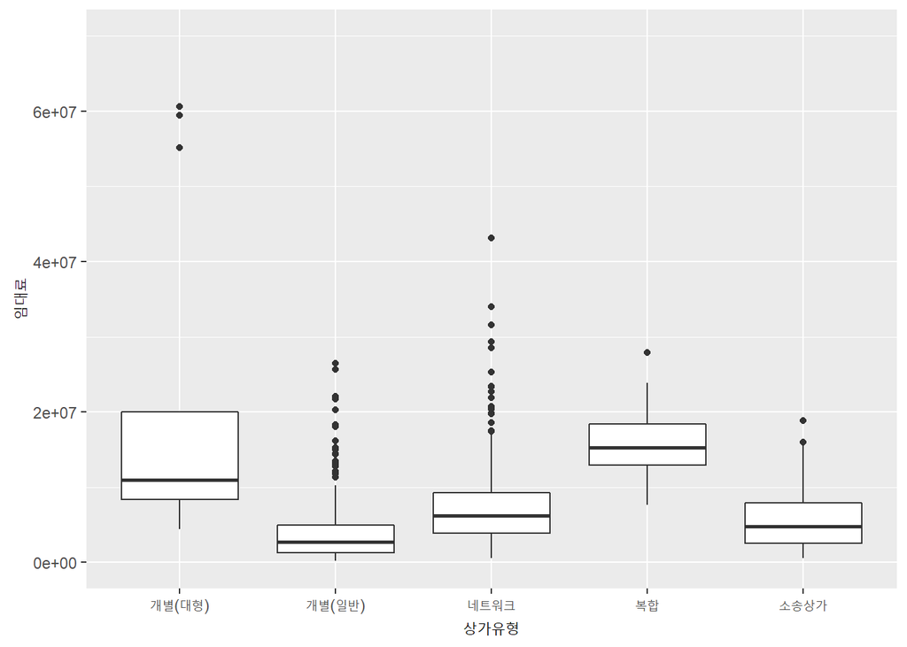

```r
ggplot(data=subway_1, aes(x=상가유형,y=임대료,group=상가유형)) + geom_boxplot() +  ylim(0, 70000000)
```

```r
subway_2 <- subway_1 %>% filter(상가유형 == "개별(대형)")
summary(subway_2$임대료)
```

```
##     Min.  1st Qu.   Median     Mean  3rd Qu.     Max.
##  4433300  8335000 10982800 21458462 20000000 60600000
```

```r
subway_3 <- subway_1 %>% filter(상가유형 == "개별(일반)")
summary(subway_3$임대료)
```

```
##     Min.  1st Qu.   Median     Mean  3rd Qu.     Max.
##   201000  1300000  2712000  3879444  4925000 26510100
```

```r
subway_4 <- subway_1 %>% filter(상가유형 == "네트워크")
summary(subway_4$임대료)
```

```
##     Min.  1st Qu.   Median     Mean  3rd Qu.     Max.
##   563552  3922883  6190489  7726787  9284039 43165260
```

```r
subway_5 <- subway_1 %>% filter(상가유형 == "복합")
summary(subway_5$임대료)
```

```
##     Min.  1st Qu.   Median     Mean  3rd Qu.     Max.
##  7674176 12893314 15254726 16145202 18442200 27943265
```

```r
subway_6 <- subway_1 %>% filter(상가유형 == "소송상가")
summary(subway_6$임대료)
```

```
##     Min.  1st Qu.   Median     Mean  3rd Qu.     Max.
##   583500  2564170  4780000  5872841  7891508 18838948
```

```r
s_i <- subway_1 %>% group_by(상가유형) %>% summarise(mean_i=mean(임대료), sum_i=sum(임대료))
View(s_i)
```

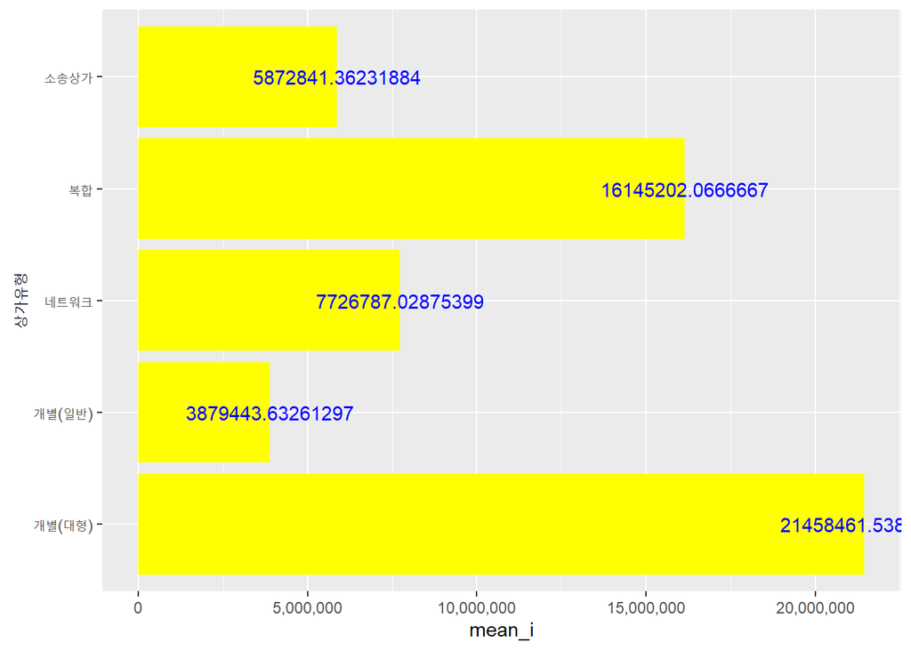

```r
ggplot(s_i, aes(상가유형, mean_i)) + geom_col(fill="yellow") + coord_flip() + scale_y_continuous(labels = scales::comma) + geom_text(aes(y=mean_i,label=mean_i),col="blue")
```

```r
with(subway_1, shapiro.test(임대료[상가유형=="개별(대형)"]))
```

```
##
##  Shapiro-Wilk normality test
##
## data:  임대료[상가유형 == "개별(대형)"]
## W = 0.69098, p-value = 0.0004514
```

```r
with(subway_1, shapiro.test(임대료[상가유형=="개별(일반)"]))
```

```
##
##  Shapiro-Wilk normality test
##
## data:  임대료[상가유형 == "개별(일반)"]
## W = 0.76025, p-value < 2.2e-16
```

```r
with(subway_1, shapiro.test(임대료[상가유형=="네트워크"]))
```

```
##
##  Shapiro-Wilk normality test
##
## data:  임대료[상가유형 == "네트워크"]
## W = 0.80553, p-value < 2.2e-16
```

```r
with(subway_1, shapiro.test(임대료[상가유형=="소송상가"]))
```

```
##
##  Shapiro-Wilk normality test
##
## data:  임대료[상가유형 == "소송상가"]
## W = 0.8839, p-value = 1.08e-05
```

```r
with(subway_1, shapiro.test(임대료[상가유형=="복합"]))
```

```
##
##  Shapiro-Wilk normality test
##
## data:  임대료[상가유형 == "복합"]
## W = 0.95097, p-value = 0.5399
```

```r
out = aov(임대료 ~ 상가유형, data=subway_1)
shapiro.test(resid(out))
```

```
##
##  Shapiro-Wilk normality test
##
## data:  resid(out)
## W = 0.78199, p-value < 2.2e-16
```

```r
bartlett.test(임대료~상가유형,data=subway_1)
```

```
##
##  Bartlett test of homogeneity of variances
##
## data:  임대료 by 상가유형
## Bartlett's K-squared = 244.41, df = 4, p-value < 2.2e-16
```

```r
TukeyHSD(out)
```

```
##   Tukey multiple comparisons of means
##     95% family-wise confidence level
##
## Fit: aov(formula = 임대료 ~ 상가유형, data = subway_1)
##
## $상가유형
##                            diff         lwr          upr     p adj
## 개별(일반)-개별(대형) -17579018 -21663092.2 -13494943.65 0.0000000
## 네트워크-개별(대형)   -13731675 -17847471.1  -9615877.94 0.0000000
## 복합-개별(대형)        -5313259 -10823247.5    196728.56 0.0648883
## 소송상가-개별(대형)   -15585620 -19982045.0 -11189195.37 0.0000000
## 네트워크-개별(일반)     3847343   2802878.6   4891808.16 0.0000000
## 복합-개별(일반)        12265758   8456415.5  16075101.34 0.0000000
## 소송상가-개별(일반)     1993398    128008.7   3858786.80 0.0293698
## 복합-네트워크           8418415   4575081.6  12261748.52 0.0000000
## 소송상가-네트워크      -1853946  -3787800.7     79909.36 0.0675352
## 소송상가-복합         -10272361 -14414821.6  -6129899.85 0.0000000
```

```r
kruskalmc(subway_1$임대료, subway_1$상가유형)
```

```
## Multiple comparison test after Kruskal-Wallis
## p.value: 0.05
## Comparisons
##                         obs.dif critical.dif difference
## 개별(대형)-개별(일반) 434.28313    209.27308       TRUE
## 개별(대형)-네트워크   195.96903    210.89857      FALSE
## 개별(대형)-복합        62.22564    282.33869      FALSE
## 개별(대형)-소송상가   280.30045    225.27831       TRUE
## 개별(일반)-네트워크   238.31410     53.51968       TRUE
## 개별(일반)-복합       496.50878    195.19550       TRUE
## 개별(일반)-소송상가   153.98269     95.58487       TRUE
## 네트워크-복합         258.19468    196.93722       TRUE
## 네트워크-소송상가      84.33141     99.09315      FALSE
## 복합-소송상가         342.52609    212.26488       TRUE
```

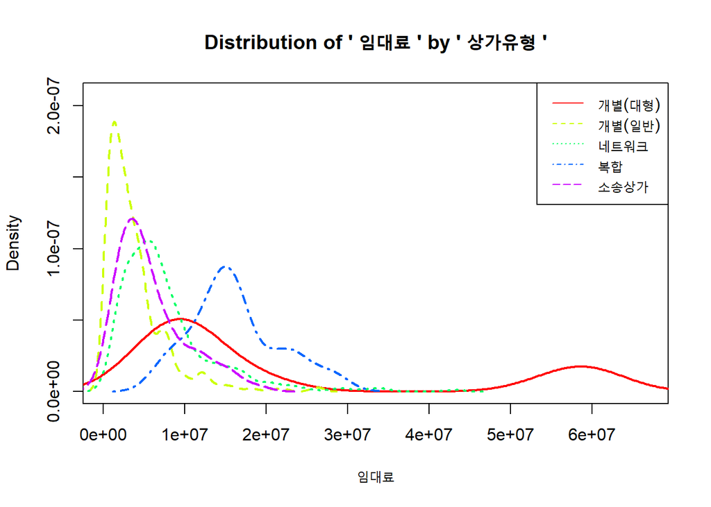

```r
library(moonBook)
moonBook::densityplot(임대료 ~ 상가유형, data = subway_1)
```

```r
table(is.na(subway_1$면적))
```

```
##
## FALSE
##   919
```

```r
subway_m <- subway_1[!is.na(subway_1$면적),]
table(is.na(subway_m$면적))
```

```
##
## FALSE
##   919
```

```r
View(subway_m)
str(subway_m)
```

```
## 'data.frame':    919 obs. of  11 variables:
##  $ NO      : int  1 2 3 4 5 8 10 11 12 13 ...
##  $ 상가유형: chr  "개별(일반)" "소송상가" "네트워크" "개별(일반)" ...
##  $ 호선    : chr  "1호선" "1호선" "1호선" "1호선" ...
##  $ 역명    : chr  "서울역_1" "서울역_1" "서울역_1" "시청_1" ...
##  $ 상가번호: chr  "150-107" "150-109" "150-110" "151-101" ...
##  $ 면적    : num  33 12 41.3 29.7 57.6 ...
##  $ 영업업종: chr  "사무실" "커피" "화장품" "의류" ...
##  $ 보호업종: chr  "" "" "" "" ...
##  $ 계약시작: chr  "2019-05-08" "2012-05-21" "2015-09-05" "2017-04-04" ...
##  $ 계약종료: chr  "2024-06-06" "2017-07-10" "2020-11-03" "2022-05-03" ...
##  $ 임대료  : num  527100 5178550 17414416 3858954 1858300 ...
```

```r
subway_max <- subway_m %>% group_by(역명) %>% summarise(sum_n=sum(임대료),sum_a=sum(면적)) %>% mutate(area_rent = round(sum_n/sum_a),2) %>% arrange(desc(area_rent)) %>% head(10)
View(subway_max)
str(subway_max)
```

```
## tibble [10 x 5] (S3: tbl_df/tbl/data.frame)
##  $ 역명     : chr [1:10] "신촌" "고속터미널_3" "영등포구청_2" "강남" ...
##  $ sum_n    : num [1:10] 1.03e+08 5.58e+07 2.78e+07 1.24e+08 7.83e+06 ...
##  $ sum_a    : num [1:10] 143.7 78.5 40.3 183.2 12 ...
##  $ area_rent: num [1:10] 719144 710042 689631 678163 652809 ...
##  $ 2        : num [1:10] 2 2 2 2 2 2 2 2 2 2
```

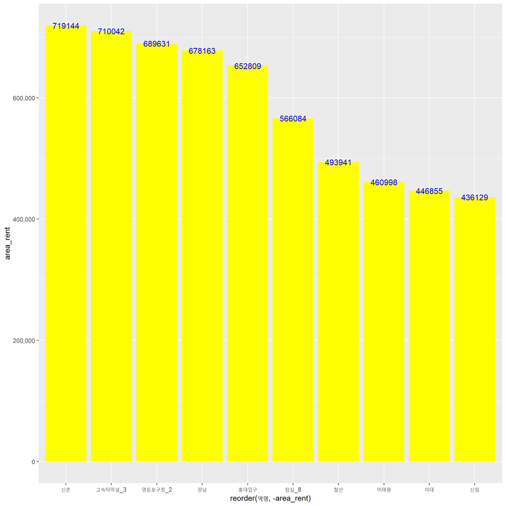

```r
ggplot(subway_max, aes(reorder(역명, -area_rent),area_rent)) + geom_col(fill="yellow") + scale_y_continuous(labels = scales::comma) + geom_text(aes(y=area_rent,label=area_rent),col="blue", size=4)
```

```r
subway_min <- subway_m %>% filter(임대료 != 0) %>% group_by(역명) %>% summarise(sum_n=sum(임대료),sum_a=sum(면적)) %>% mutate( area_rent = round(sum_n/sum_a),2) %>% arrange(area_rent) %>% head(10)
```

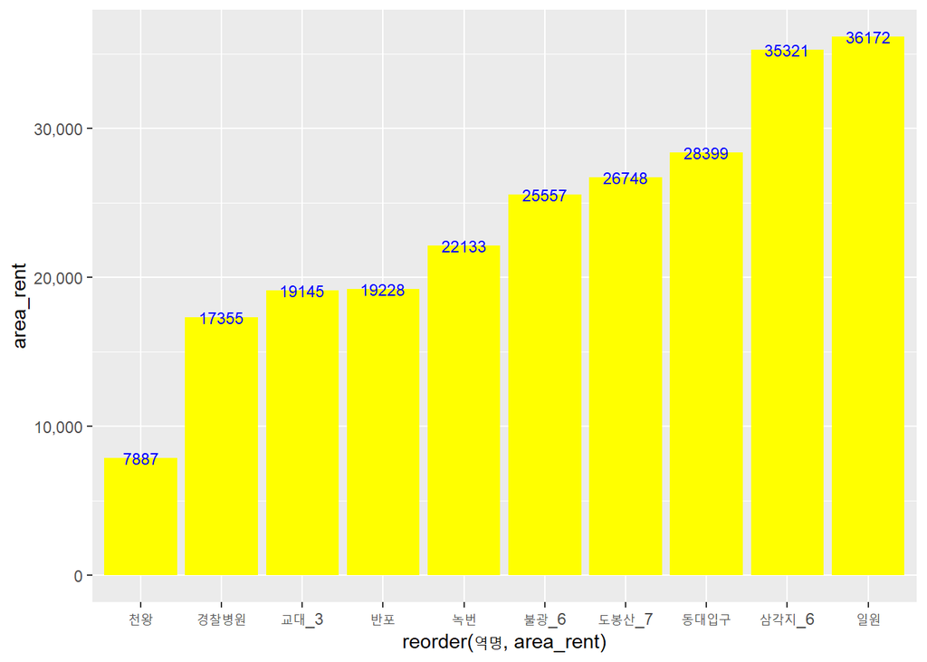

```r
View(subway_min)
ggplot(subway_min, aes(reorder(역명, area_rent),area_rent)) + geom_col(fill="yellow") + scale_y_continuous(labels = scales::comma) + geom_text(aes(y=area_rent,label=area_rent),col="blue", size=3)
```

```r
out = aov(임대료 ~ 면적, data =subway_m)
out
```

```
## Call:
##    aov(formula = 임대료 ~ 면적, data = subway_m)
##
## Terms:
##                         면적    Residuals
## Sum of Squares  4.028606e+15 2.967242e+16
## Deg. of Freedom            1          917
##
## Residual standard error: 5688422
## Estimated effects may be unbalanced
```

```r
shapiro.test(resid(out))
```

```
##
##  Shapiro-Wilk normality test
##
## data:  resid(out)
## W = 0.78211, p-value < 2.2e-16
```

```r
cor(subway_m$면적, subway_m$임대료, method = "pearson")
```

```
## [1] 0.3457449
```

```r
cor(subway_m$면적, subway_m$임대료, method = "spearman")
```

```
## [1] 0.3667153
```

```r
cor(subway_m$면적, subway_m$임대료, method = "kendal")
```

```
## [1] 0.2577473
```

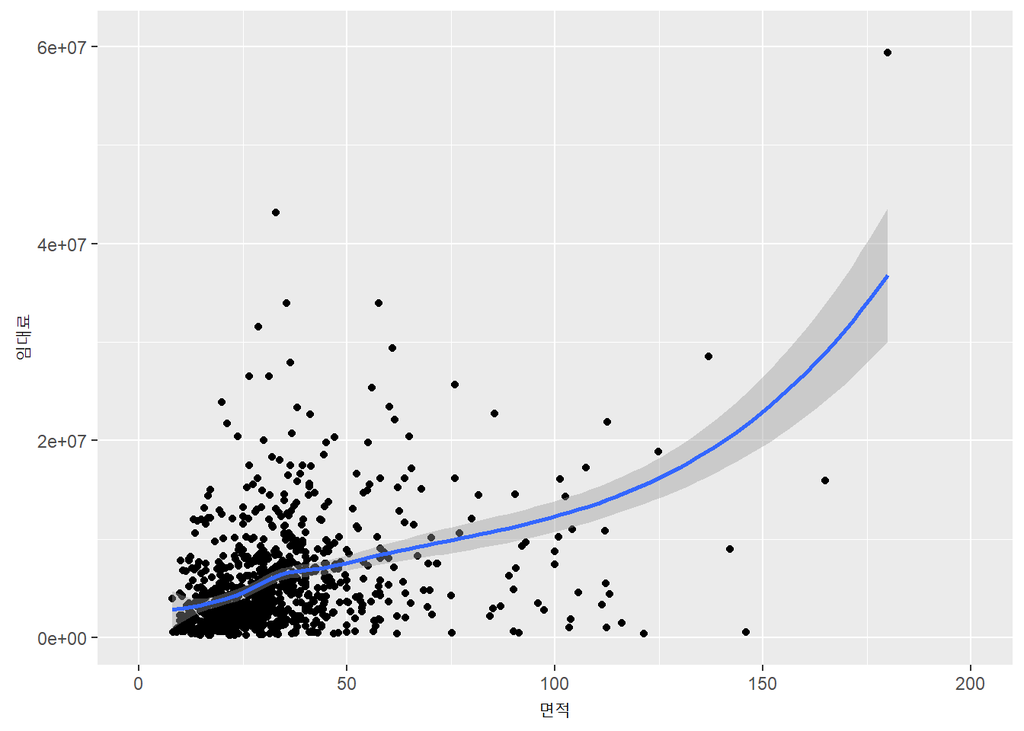

```r
ggplot(subway_m, aes(면적, 임대료) ) + geom_point() + stat_smooth() +xlim(0,200)
```

2-3. 영업업종에 따른 임대료의 차이 : 영업업종 대비 임대료를 가장 많이 또는 적게 내는 곳은? / 영업업종은 임대료에 영향을 주는가?

```r
subway$"임대료"[is.na(subway$"임대료")] <-0
table(subway_1$영업업종)
```

```
##
##                                          H&B드럭스토어 등
##                            6                            1
##                     가구판매                         가방
##                            1                            1
##                     간이음식                     건강식품
##                            9                            7
##                         공실                     공익상가
##                            1                            3
##                         과일                         구두
##                            1                            1
##                     귀금속류                     규방공예
##                            2                            1
##                       금융업                           꽃
##                            3                           26
##                     낚시용품                     네일아트
##                            1                            1
##                       농산물                       다이소
##                            7                            1
##               디저트(완제품)                           떡
##                            2                            3
## 멀티편의공간(다이소 및 카페)                       메디컬
##                            1                            2
##                         명함                     문화복지
##                            1                            3
##               물품보관서비스                     베이커리
##                            1                            4
##                       보청기                         분식
##                            1                           17
##                       사무실                     생활용품
##                           30                            4
##                         서점                         속옷
##                            4                            1
##                       수공업                     수입과자
##                            1                            7
##                 스포츠용품점                     시계수리
##                            5                            1
##                         식음                         신발
##                            5                           10
##                   아이스크림                         안경
```

[output cut: 22 more lines]

```
##                            1                            1
##                     패션잡화                       팬시품
##                            6                            1
##                       편의점                     푸른마을
##                          186                            4
##                   한복대여점                 한지공예공방
##                            1                            1
##                       핸드폰                         헬스
##                           15                            2
##                     혈액센터                   홍보/ 전시
##                            1                            1
##                         화실                       화장품
##                            1                           50
##                         화훼                     휴게음식
##                            4                            4
```

```r
View(subway)
subway_2 <- subway_1 %>%group_by(영업업종) %>% arrange(desc(임대료))
View(subway_2)
sales_rent <- subway_1 %>% group_by(영업업종) %>% summarise(mean_i=round(mean(임대료),2)) %>% filter(영업업종 != "" & mean_i <= 30000000) %>%  arrange(desc(mean_i)) %>% head(10)
```

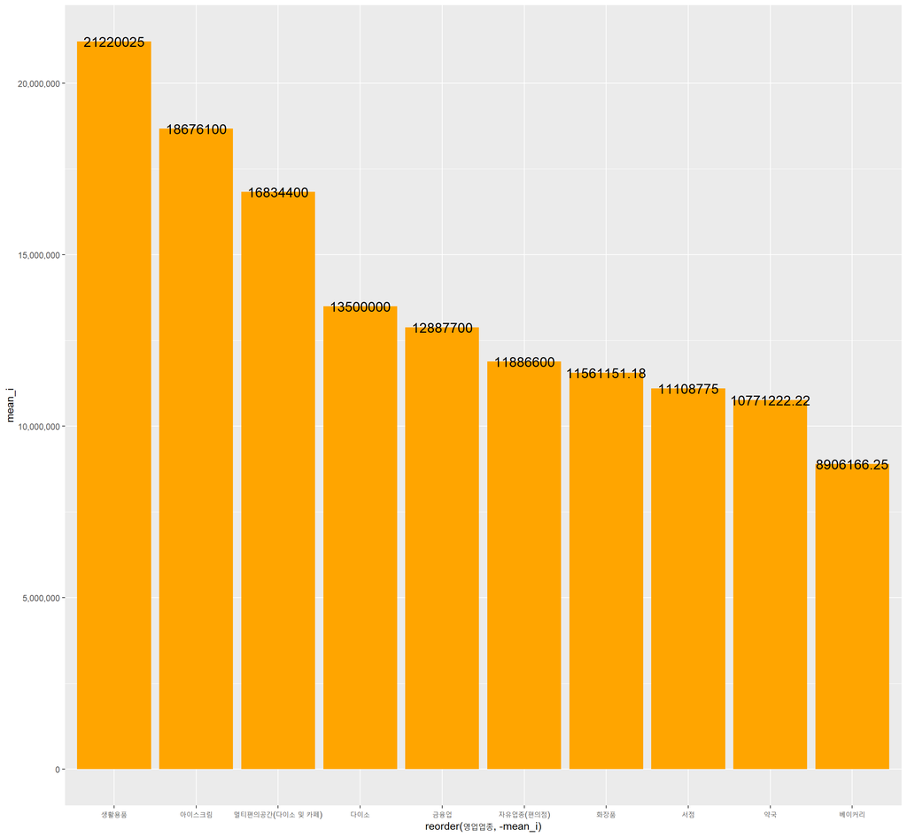

```r
View(sales_rent)
ggplot(sales_rent, aes(reorder(영업업종, -mean_i), mean_i)) + geom_col(fill="orange") + scale_y_continuous(labels = scales::comma) + geom_text(aes(y=mean_i,label=mean_i),col="black", size=5)
```

```r
sales_rent <- subway_1 %>% filter(영업업종 != "") %>% group_by(영업업종) %>% summarise(mean_i=round(mean(임대료),2)) %>% arrange(mean_i) %>% head(10)
```

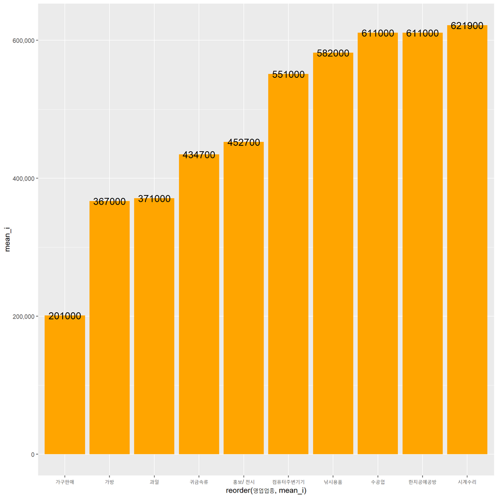

```r
View(sales_rent)
ggplot(sales_rent, aes(reorder(영업업종, mean_i), mean_i)) + geom_col(fill="orange") + scale_y_continuous(labels = scales::comma) + geom_text(aes(y=mean_i,label=mean_i),col="black", size=5)
```

2-4. 호선별 임대료가 가장 높은 호선은?

```r
#호선별
table(subway_1$호선)
```

```
##
## 1호선 2호선 3호선 4호선 5호선 6호선 7호선 8호선
##    18   216   110   110   187    91   154    33
```

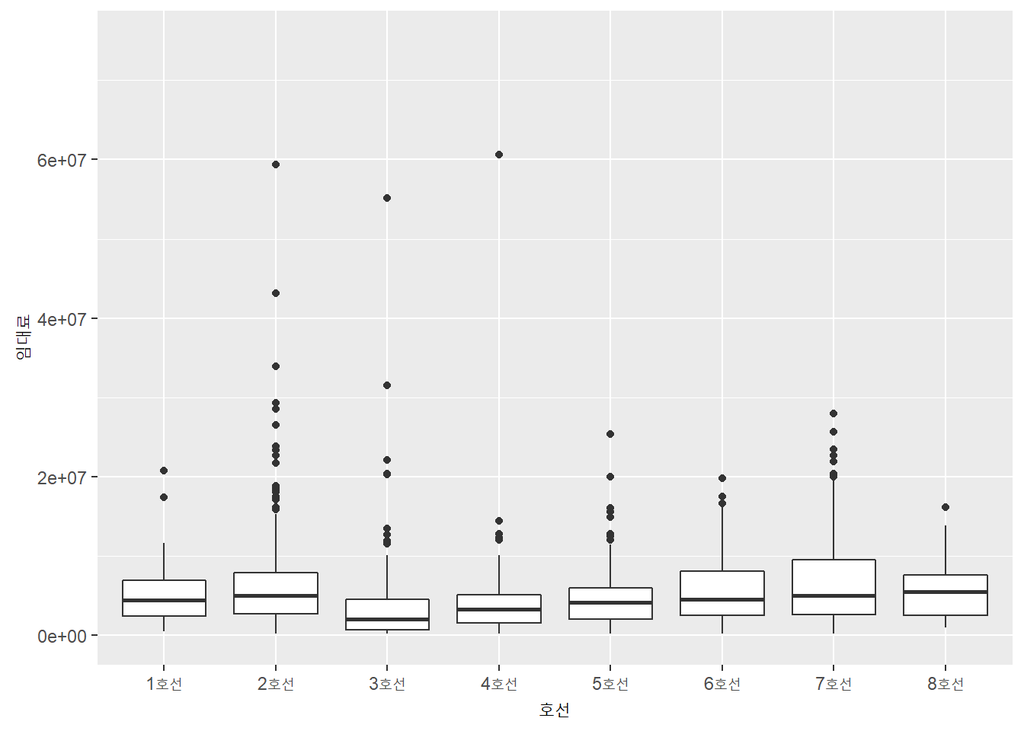

```r
ggplot(data=subway_1, aes(x=호선,y=임대료,group=호선)) + geom_boxplot() + ylim(0,7.5e+07)
```

```r
line_rent <- subway_1 %>%  group_by(호선) %>% summarise(mean_i=round(mean(임대료),0))
View(line_rent)
subway_color <- c("1호선"= "#234794", "2호선"="#009900", "3호선" = "#F39800", "4호선" = "#90D7EC", "5호선"="#705DA8",
                  "6호선"="#D16F15", "7호선"="#808000","8호선"="#F58F98")
subway_color
```

```
##     1호선     2호선     3호선     4호선     5호선     6호선     7호선     8호선
## "#234794" "#009900" "#F39800" "#90D7EC" "#705DA8" "#D16F15" "#808000" "#F58F98"
```

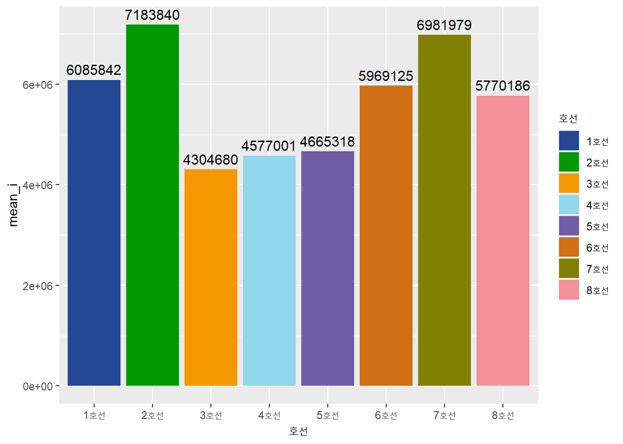

```r
ggplot(line_rent, aes(호선, mean_i, fill=호선)) + geom_bar(stat='identity') +scale_fill_manual(values=subway_color) + geom_text(aes(y=mean_i,label=mean_i),col="black", size=4, vjust=-0.5)
```

```r
View(passenger)
people <- passenger %>% group_by(호선) %>% summarise(sum_p=sum(일평균))
View(people)
```

```r
with(subway_1, shapiro.test(임대료[호선=="1호선"]))
```

```
##
##  Shapiro-Wilk normality test
##
## data:  임대료[호선 == "1호선"]
## W = 0.80484, p-value = 0.001779
```

```r
with(subway_1, shapiro.test(임대료[호선=="2호선"]))
```

```
##
##  Shapiro-Wilk normality test
##
## data:  임대료[호선 == "2호선"]
## W = 0.70158, p-value < 2.2e-16
```

```r
with(subway_1, shapiro.test(임대료[호선=="3호선"]))
```

```
##
##  Shapiro-Wilk normality test
##
## data:  임대료[호선 == "3호선"]
## W = 0.53466, p-value < 2.2e-16
```

```r
with(subway_1, shapiro.test(임대료[호선=="4호선"]))
```

```
##
##  Shapiro-Wilk normality test
##
## data:  임대료[호선 == "4호선"]
## W = 0.47508, p-value < 2.2e-16
```

```r
with(subway_1, shapiro.test(임대료[호선=="5호선"]))
```

```
##
##  Shapiro-Wilk normality test
##
## data:  임대료[호선 == "5호선"]
## W = 0.84913, p-value = 1.225e-12
```

```r
with(subway_1, shapiro.test(임대료[호선=="6호선"]))
```

```
##
##  Shapiro-Wilk normality test
##
## data:  임대료[호선 == "6호선"]
## W = 0.90611, p-value = 6.916e-06
```

```r
with(subway_1, shapiro.test(임대료[호선=="7호선"]))
```

```
##
##  Shapiro-Wilk normality test
##
## data:  임대료[호선 == "7호선"]
## W = 0.87628, p-value = 5.119e-10
```

```r
with(subway_1, shapiro.test(임대료[호선=="8호선"]))
```

```
##
##  Shapiro-Wilk normality test
##
## data:  임대료[호선 == "8호선"]
## W = 0.91267, p-value = 0.01154
```

```r
out = aov(임대료 ~ 호선, data=subway_1)
shapiro.test(resid(out))
```

```
##
##  Shapiro-Wilk normality test
##
## data:  resid(out)
## W = 0.72056, p-value < 2.2e-16
```

```r
bartlett.test(임대료~호선,data=subway_1)
```

```
##
##  Bartlett test of homogeneity of variances
##
## data:  임대료 by 호선
## Bartlett's K-squared = 114.78, df = 7, p-value < 2.2e-16
```

```r
TukeyHSD(out)
```

```
##   Tukey multiple comparisons of means
##     95% family-wise confidence level
##
## Fit: aov(formula = 임대료 ~ 호선, data = subway_1)
##
## $호선
##                    diff        lwr       upr     p adj
## 2호선-1호선  1097997.50 -3347858.0 5543853.0 0.9953647
## 3호선-1호선 -1781162.17 -6388848.8 2826524.4 0.9390963
## 4호선-1호선 -1508841.90 -6116528.5 3098844.7 0.9751895
## 5호선-1호선 -1420524.82 -5892819.6 3051769.9 0.9791351
## 6호선-1호선  -116717.28 -4791558.3 4558123.7 1.0000000
## 7호선-1호선   896137.00 -3618035.5 5410309.5 0.9988420
## 8호선-1호선  -315656.63 -5625753.1 4994439.8 0.9999997
## 3호선-2호선 -2879159.67 -5001896.4 -756423.0 0.0010708
## 4호선-2호선 -2606839.39 -4729576.1 -484102.7 0.0049802
## 5호선-2호선 -2518522.31 -4328675.7 -708368.9 0.0006848
## 6호선-2호선 -1214714.77 -3479526.8 1050097.2 0.7324007
## 7호선-2호선  -201860.49 -2113139.9 1709418.9 0.9999831
## 8호선-2호선 -1413654.12 -4800741.3 1973433.0 0.9104505
## 4호선-3호선   272320.27 -2171274.6 2715915.1 0.9999756
## 5호선-3호선   360637.35 -1816930.1 2538204.8 0.9996473
## 6호선-3호선  1664444.89  -903534.5 4232424.3 0.5035332
## 7호선-3호선  2677299.18   414970.0 4939628.4 0.0081761
## 8호선-3호선  1465505.55 -2131368.7 5062379.8 0.9204813
## 5호선-4호선    88317.08 -2089250.4 2265884.6 1.0000000
## 6호선-4호선  1392124.62 -1175854.8 3960104.0 0.7214470
## 7호선-4호선  2404978.90   142649.7 4667308.1 0.0279980
## 8호선-4호선  1193185.27 -2403688.9 4790059.5 0.9733152
## 6호선-5호선  1303807.54 -1012474.5 3620089.6 0.6807574
## 7호선-5호선  2316661.82   344663.4 4288660.3 0.0089787
## 8호선-5호선  1104868.19 -2316849.0 4526585.4 0.9770838
## 7호선-6호선  1012854.28 -1383287.6 3408996.2 0.9047385
## 8호선-6호선  -198939.35 -3881447.5 3483568.8 0.9999998
## 8호선-7호선 -1211793.63 -4688067.8 2264480.5 0.9648739
```

```r
kruskalmc(subway_1$임대료, subway_1$호선)
```

```
## Multiple comparison test after Kruskal-Wallis
## p.value: 0.05
## Comparisons
##                obs.dif critical.dif difference
## 1호선-2호선  32.458333    203.41360      FALSE
## 1호선-3호선 168.997980    210.81794      FALSE
## 1호선-4호선 100.525253    210.81794      FALSE
## 1호선-5호선  60.971777    204.62329      FALSE
## 1호선-6호선  14.891331    213.89049      FALSE
## 1호선-7호선  38.396825    206.53934      FALSE
## 1호선-8호선  20.626263    242.95567      FALSE
## 2호선-3호선 201.456313     97.12270       TRUE
## 2호선-4호선 132.983586     97.12270       TRUE
## 2호선-5호선  93.430110     82.82091       TRUE
## 2호선-6호선  17.567002    103.62315      FALSE
## 2호선-7호선   5.938492     87.44778      FALSE
## 2호선-8호선  11.832071    154.97120      FALSE
## 3호선-4호선  68.472727    111.80310      FALSE
## 3호선-5호선 108.026203     99.63141       TRUE
## 3호선-6호선 183.889311    117.49413       TRUE
## 3호선-7호선 207.394805    103.50955       TRUE
## 3호선-8호선 189.624242    164.56970       TRUE
## 4호선-5호선  39.553476     99.63141      FALSE
## 4호선-6호선 115.416583    117.49413      FALSE
## 4호선-7호선 138.922078    103.50955       TRUE
## 4호선-8호선 121.151515    164.56970      FALSE
## 5호선-6호선  75.863107    105.97809      FALSE
## 5호선-7호선  99.368602     90.22590       TRUE
## 5호선-8호선  81.598039    156.55565      FALSE
## 6호선-7호선  23.505495    109.63196      FALSE
## 6호선-8호선   5.734932    168.48776      FALSE
## 7호선-8호선  17.770563    159.05182      FALSE
```

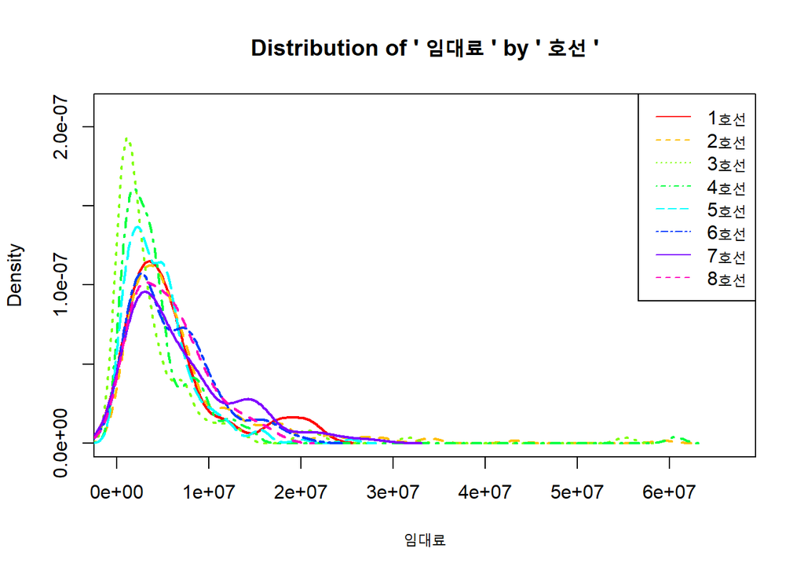

```r
library(moonBook)
moonBook::densityplot(임대료 ~ 호선, data = subway_1)
```

2-5. 역별 임대료가 가장 높은 역은?

```r
#역별

View(subway)
station_rent <- subway_1
station_rent$역명 <- gsub("_[0-9]","",station_rent$역명)
str(station_rent)
```

```
## 'data.frame':    919 obs. of  11 variables:
##  $ NO      : int  1 2 3 4 5 8 10 11 12 13 ...
##  $ 상가유형: chr  "개별(일반)" "소송상가" "네트워크" "개별(일반)" ...
##  $ 호선    : chr  "1호선" "1호선" "1호선" "1호선" ...
##  $ 역명    : chr  "서울역" "서울역" "서울역" "시청" ...
##  $ 상가번호: chr  "150-107" "150-109" "150-110" "151-101" ...
##  $ 면적    : num  33 12 41.3 29.7 57.6 ...
##  $ 영업업종: chr  "사무실" "커피" "화장품" "의류" ...
##  $ 보호업종: chr  "" "" "" "" ...
##  $ 계약시작: chr  "2019-05-08" "2012-05-21" "2015-09-05" "2017-04-04" ...
##  $ 계약종료: chr  "2024-06-06" "2017-07-10" "2020-11-03" "2022-05-03" ...
##  $ 임대료  : num  527100 5178550 17414416 3858954 1858300 ...
```

```r
station_rent_mean <- station_rent %>% group_by(역명) %>% summarise(mean_i=round(mean(임대료),2), sum_i=sum(임대료)) %>% arrange(desc(mean_i)) %>% head(10)
```

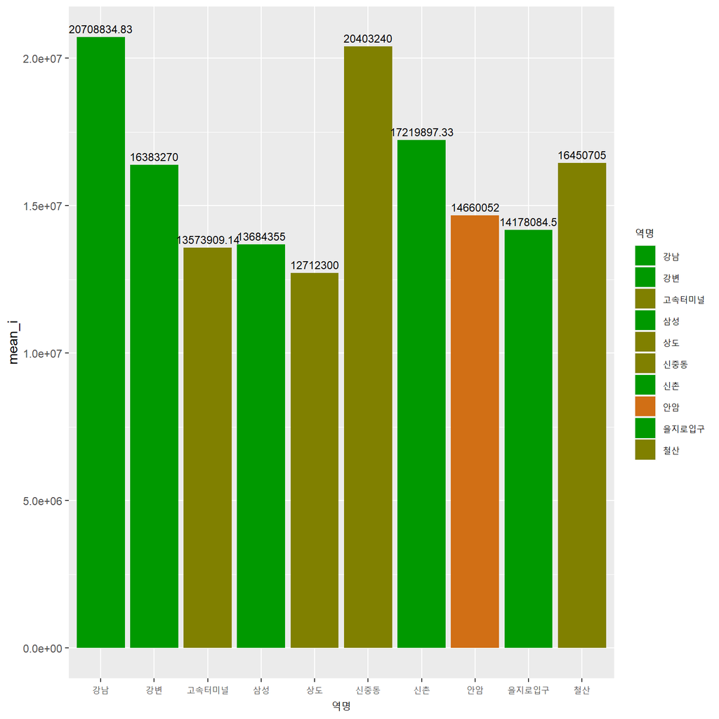

```r
View(station_rent)
st_color <- c("강남"= "#009900", "신중동"="#808000", "신촌" = "#009900", "철산" = "#808000", "강변"="#009900",
                  "안암"="#D16F15", "을지로입구"="#009900","삼성"="#009900", "고속터미널" = "#808000", "상도"="#808000")

ggplot(station_rent_mean, aes(역명, mean_i,fill= 역명)) + geom_bar(stat='identity')  + geom_text(aes(y=mean_i,label=mean_i),col="black", size=3, vjust=-0.5) +scale_fill_manual(values=st_color)
```

```r
station_rent_min <- station_rent %>% group_by(역명) %>% summarise(mean_i=round(mean(임대료),2), sum_i=sum(임대료)) %>% arrange(mean_i) %>% head(10)
str(station_rent_min)
```

```
## tibble [10 x 3] (S3: tbl_df/tbl/data.frame)
##  $ 역명  : chr [1:10] "동대입구" "경찰병원" "녹번" "이촌" ...
##  $ mean_i: num [1:10] 749767 819150 881275 1092714 1096650 ...
##  $ sum_i : num [1:10] 5248367 1638300 3525100 2185427 2193300 ...
```

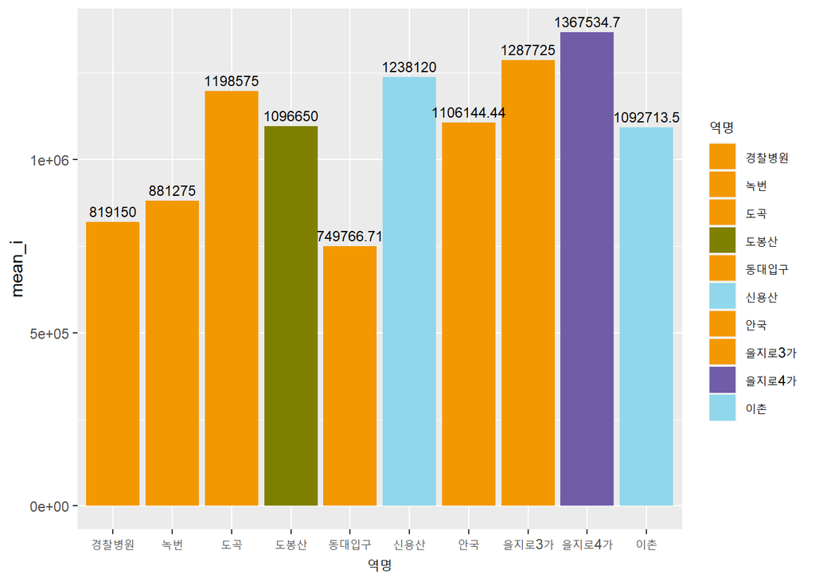

```r
st_min_color <- c("경찰병원"= "#F39800", "녹번"="#F39800", "도곡" = "#F39800", "도봉산" = "#808000", "동대입구"="#F39800",
                  "신용산"="#90D7EC", "안국"="#F39800","을지로3가"="#F39800", "을지로4가" = "#705DA8", "이촌"="#90D7EC")
ggplot(station_rent_min, aes(역명, mean_i,fill= 역명)) + geom_bar(stat='identity')  + geom_text(aes(y=mean_i,label=mean_i),col="black", size=3, vjust=-0.5) +scale_fill_manual(values=st_min_color)
```

2-6. 승하차인원이 많은 곳일수록 임대료를 많이 낼까?

```r
st_rent <- subway_1 %>%  group_by(역명) %>% summarise(mean_i=mean(임대료), sum_i=sum(임대료))
View(st_rent)

table(is.na(passenger$일평균))
```

```
##
## FALSE
##   277
```

```r
passenger_join <- inner_join(st_rent, passenger)
```

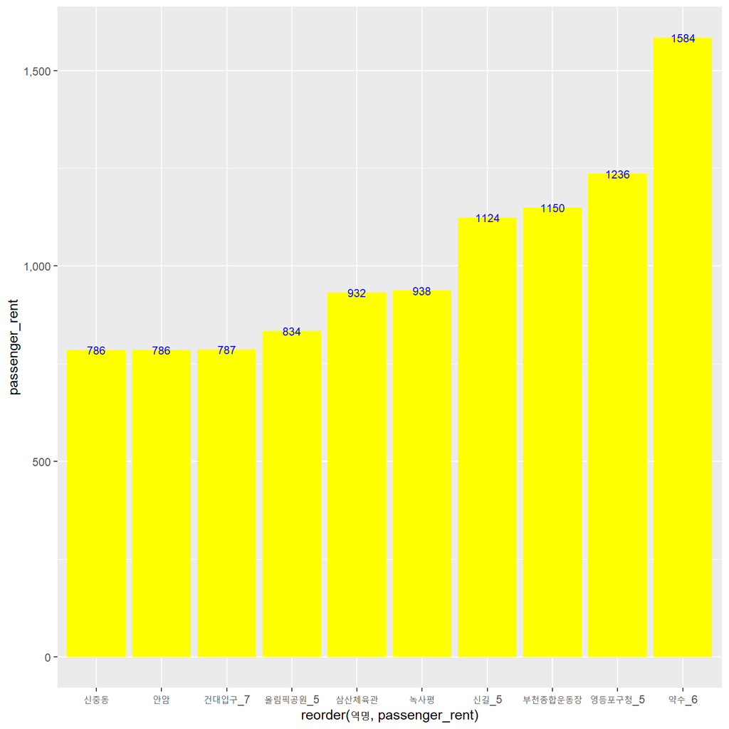

```r
View(passenger_join)

passenger_max <- passenger_join %>% filter(mean_i != 0) %>% mutate(passenger_rent = round(mean_i/일평균),0) %>% arrange(desc(passenger_rent)) %>% select(역명, mean_i, sum_i, 호선, 일평균, passenger_rent) %>% arrange(desc(passenger_rent)) %>% head(10)

View(passenger_max)

ggplot(passenger_max, aes(reorder(역명, passenger_rent), passenger_rent)) + geom_col(fill="yellow") + scale_y_continuous(labels = scales::comma) + geom_text(aes(y=passenger_rent,label=passenger_rent),col="blue", size=3)
```

```r
out = aov(임대료 ~ 면적, data =subway_m)
out
```

```
## Call:
##    aov(formula = 임대료 ~ 면적, data = subway_m)
##
## Terms:
##                         면적    Residuals
## Sum of Squares  4.028606e+15 2.967242e+16
## Deg. of Freedom            1          917
##
## Residual standard error: 5688422
## Estimated effects may be unbalanced
```

```r
shapiro.test(resid(out))
```

```
##
##  Shapiro-Wilk normality test
##
## data:  resid(out)
## W = 0.78211, p-value < 2.2e-16
```

```r
cor(passenger_join$일평균, passenger_join$mean_i, method = "pearson")
```

```
## [1] 0.3624983
```

```r
cor(passenger_join$일평균, passenger_join$mean_i, method = "spearman")
```

```
## [1] 0.2436514
```

```r
cor(passenger_join$일평균, passenger_join$mean_i, method = "kendal")
```

```
## [1] 0.163045
```

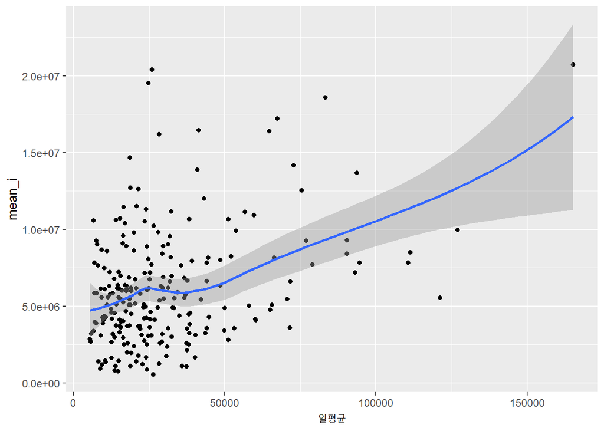

```r
ggplot(passenger_join, aes(일평균, mean_i) ) + geom_point() + stat_smooth()
```

2-7. 지하철의 혼잡도가 높은 역일 수록 임대료를 많이 낼까?

```r
congestion2 <- congestion %>% filter(조사일자 == "평일")  %>% group_by(역명) %>% mutate(아침시간 = (mean_5.30 + mean_6.00 + mean_6.30 + mean_7.00 + mean_7.30)/5,
                                                                                    출근시간 = (mean_8.00 + mean_8.30 + mean_9.00 + mean_9.30)/4,
                                                                                    오전시간 = (mean_10.00 + mean_10.30 + mean_11.00 + mean_11.30 + mean_12.00 + mean_12.30)/6,
                                                                                    오후시간 = (mean_13.00 + mean_13.30 + mean_14.00 + mean_14.30 + mean_15.00 + mean_15.30 + mean_16.00 + mean_16.30 + mean_17.00 + mean_17.30)/10,
                                                                                    퇴근시간 = (mean_18.00 + mean_18.30 + mean_19.00 + mean_19.30 + mean_20.00 + mean_20.30)/6,
                                                                                    밤시간 = (mean_21.00 + mean_21.30 + mean_22.00 + mean_22.30 + mean_23.00 + mean_23.30 + mean_24.00 + mean_24.30)/8) %>%select(역명, 아침시간, 출근시간, 오전시간, 오후시간, 퇴근시간, 밤시간)

View(congestion2)
passenger_maxfull <- passenger_join %>% filter(mean_i != 0) %>% mutate(passenger_rent = round(mean_i/일평균),0) %>% arrange(desc(passenger_rent)) %>% select(역명, mean_i, sum_i, 호선, 일평균, passenger_rent) %>% arrange(desc(passenger_rent))
conge_pass <- inner_join(congestion2, passenger_maxfull)
View(conge_pass)
str(conge_pass)
```

[output not shown]

[output cut: 63 more lines]

[output not shown]

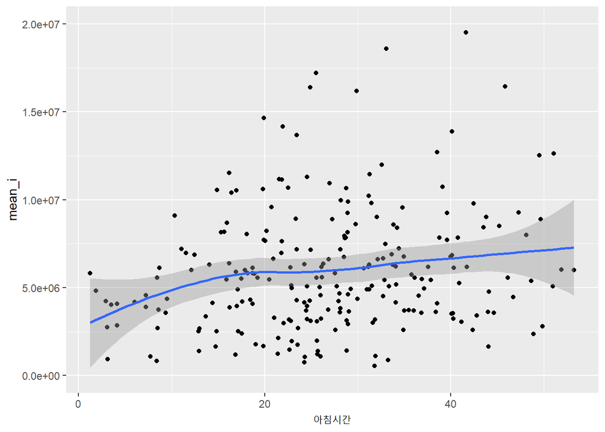

```r
#아침시간
t1_pass <- conge_pass %>% select(역명, 아침시간, passenger_rent, mean_i) %>% arrange(desc(아침시간))
ggplot(data=t1_pass, aes(x=아침시간, y=mean_i)) + geom_point()  + stat_smooth() + ylim(0,20000000)
```

```r
View(t1_pass)
```

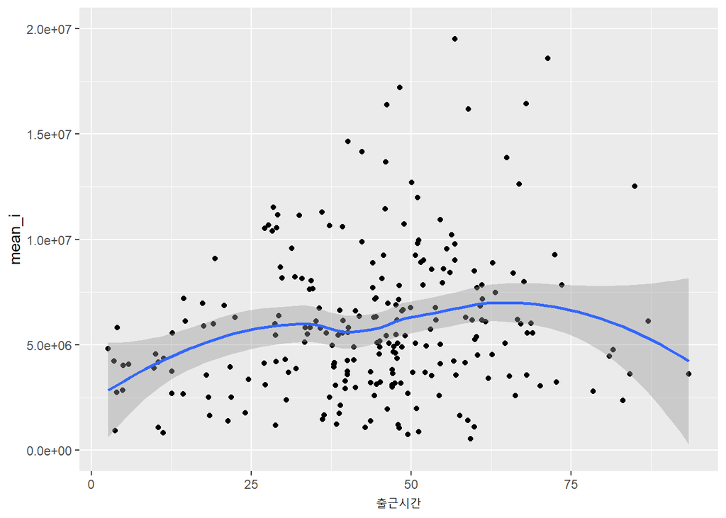

```r
#출근시간
t2_pass <- conge_pass %>% arrange(desc(출근시간)) %>% select(역명, 출근시간, passenger_rent, mean_i)
ggplot(data=t2_pass, aes(x=출근시간, y=mean_i)) + geom_point()  + stat_smooth() + ylim(0,20000000)
```

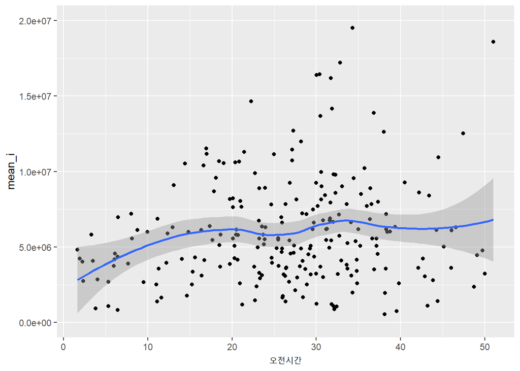

```r
#오전시간
t3_pass <- conge_pass %>% arrange(desc(오전시간)) %>% select(역명, 오전시간, passenger_rent, mean_i)
ggplot(data=t3_pass, aes(x=오전시간, y=mean_i)) + geom_point()  + stat_smooth() + ylim(0,20000000)
```

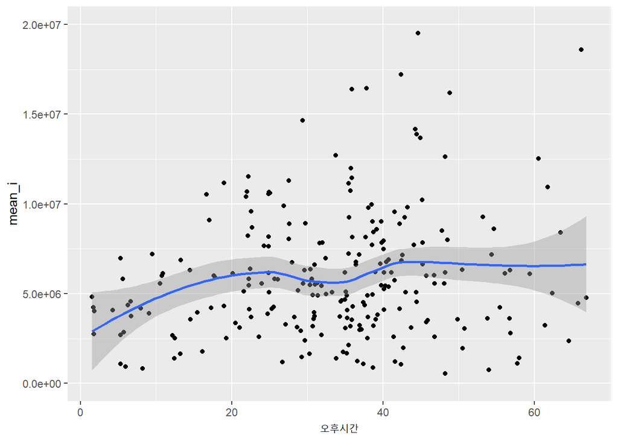

```r
#오후시간
t4_pass <- conge_pass %>% arrange(desc(오후시간)) %>% select(역명, 오후시간, passenger_rent, mean_i)
ggplot(data=t4_pass, aes(x=오후시간, y=mean_i)) + geom_point()  + stat_smooth() + ylim(0,20000000)
```

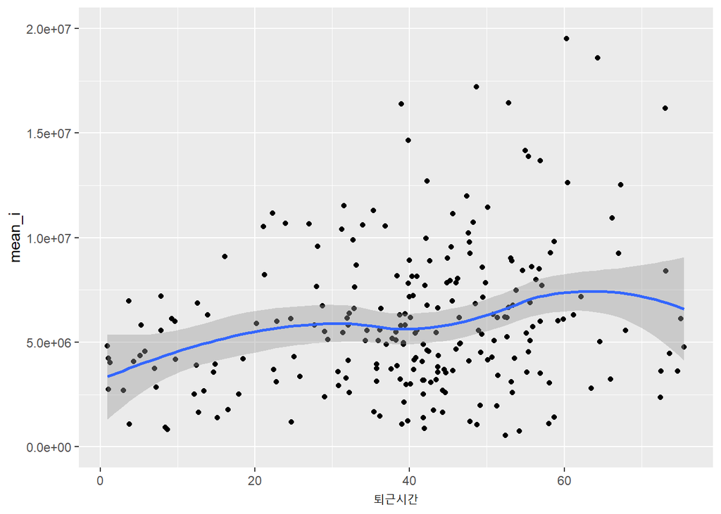

```r
#퇴근시간
t5_pass <- conge_pass %>% arrange(desc(퇴근시간)) %>% select(역명, 퇴근시간, passenger_rent, mean_i)
ggplot(data=t5_pass, aes(x=퇴근시간, y=mean_i)) + geom_point()  + stat_smooth() + ylim(0,20000000)
```

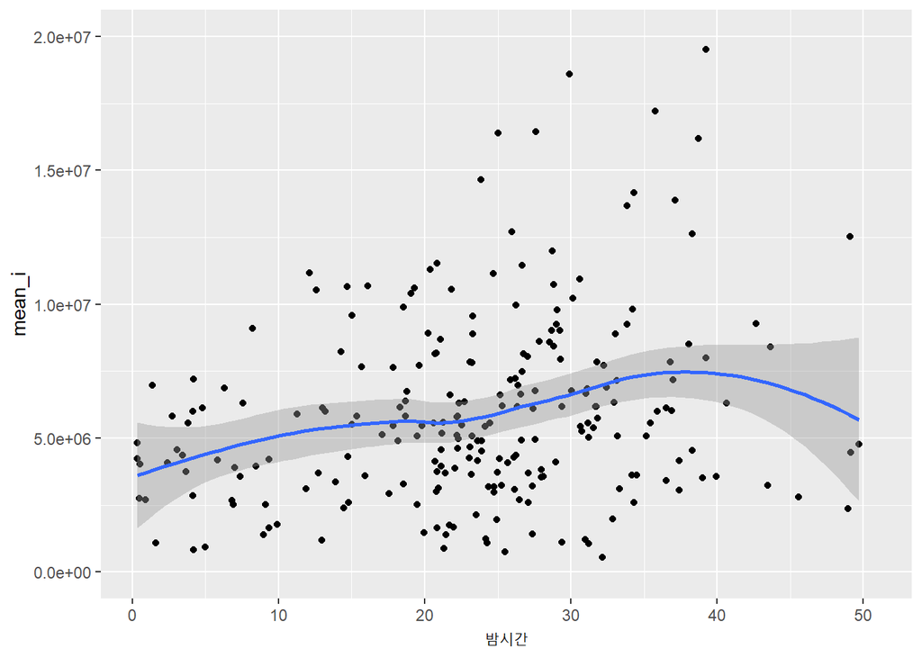

```r
# 밤시간
t6_pass <- conge_pass %>% arrange(desc(밤시간)) %>% select(역명, 밤시간, passenger_rent, mean_i)
t6_pass$passenger_rent <- ifelse(t6_pass$passenger_rent >= 4000, NA, t6_pass$passenger_rent)
ggplot(data=t6_pass, aes(x=밤시간, y=mean_i)) + geom_point()  + stat_smooth() + ylim(0,20000000)
```

2-8. 정거장이 지하이면 임대료를 많이 낼 것인가? 지상이면 많이 낼 것인가?

```r
depth_join <-  inner_join(subway_ms, depth)
View(depth_join)
table(depth_join$정거장층수)
```

```
##
##       B2       B3       B4       B5       B6       B8     고가     지상
##       98       74       28       15        3        1        1        1
## 지상역사
##       17
```

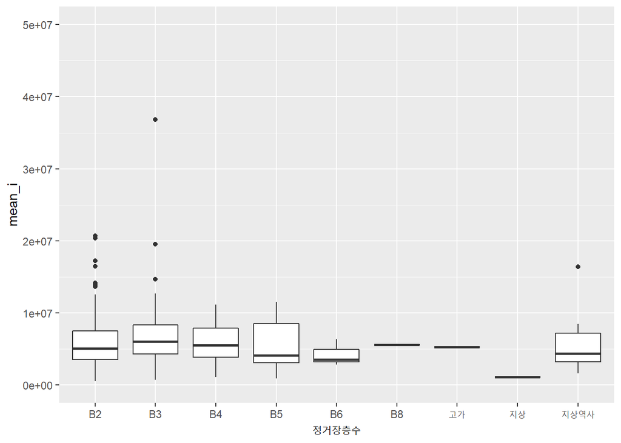

```r
ggplot(data=depth_join, aes(정거장층수, mean_i, group=정거장층수)) + geom_boxplot() + ylim(0,5.0e+07)
```

```r
depth_max <- depth_join %>% group_by(정거장층수) %>% summarise(mean_depth=mean(mean_i)) %>% filter(정거장층수!="B8" & 정거장층수!="고가"&정거장층수!="지상")
depth_max
```

```
## # A tibble: 6 x 2
##   정거장층수 mean_depth
##   <chr>           <dbl>
## 1 B2           5983090.
## 2 B3          12943453.
## 3 B4           5822561.
## 4 B5           5262001.
## 5 B6           4254068.
## 6 지상역사     5495602.
```

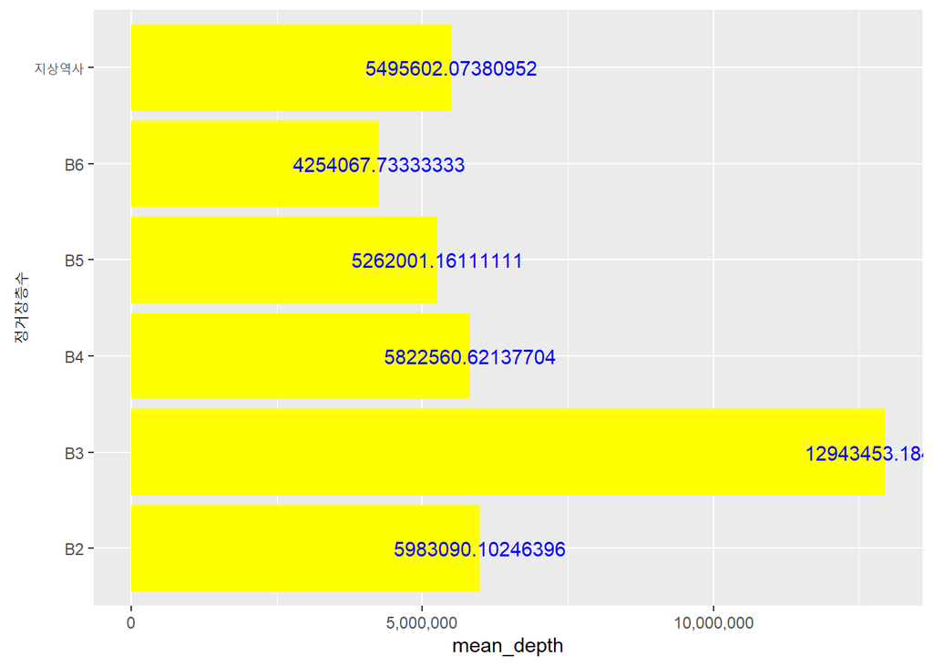

```r
ggplot(depth_max, aes(정거장층수, mean_depth)) + geom_col(fill="yellow") + coord_flip() + scale_y_continuous(labels = scales::comma) + geom_text(aes(y=mean_depth,label=mean_depth),col="blue")
```

2-9. 환승역인 역과 환승역이 아닌 곳에 임대료는 차이가 있는가?

```r
View(subway_ms)
str(subway_ms)
```

```
## tibble [241 x 3] (S3: tbl_df/tbl/data.frame)
##  $ 역명  : chr [1:241] "가락시장_8" "가산디지털단지_7" "강남" "강남구청" ...
##  $ mean_i: num [1:241] 3616269 9248338 20708835 6886401 7655720 ...
##  $ sum_i : int [1:241] 14465077 27745015 124253009 48204808 30622881 13529507 32766540 6316240 4085152 4559758 ...
```

```r
subway_tr2 <- subway_ms %>% mutate(환승여부 = ifelse(str_extract_all(subway_ms$역명, "_[0-9]") == "character(0)", "미환승역", "환승역"))
str_extract_all(subway_ms$역명, "_[0-9]")
```

[output not shown]

[output cut: 667 more lines]

[output not shown]

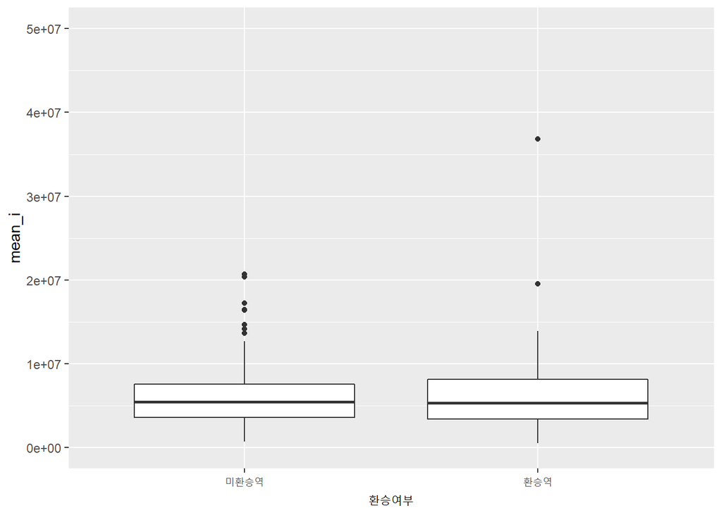

```r
ggplot(data=subway_tr2, aes(환승여부, mean_i, group=환승여부)) + geom_boxplot() + ylim(0,5.0e+07)
```

```r
View(subway_tr2)
```

```r
subway_tr <- subway_tr2 %>% group_by(환승여부) %>% summarise(mean_tr=round(mean(mean_i),2))
subway_tr
```

```
## # A tibble: 2 x 2
##   환승여부   mean_tr
##   <chr>        <dbl>
## 1 미환승역  6533944.
## 2 환승역   11289600.
```

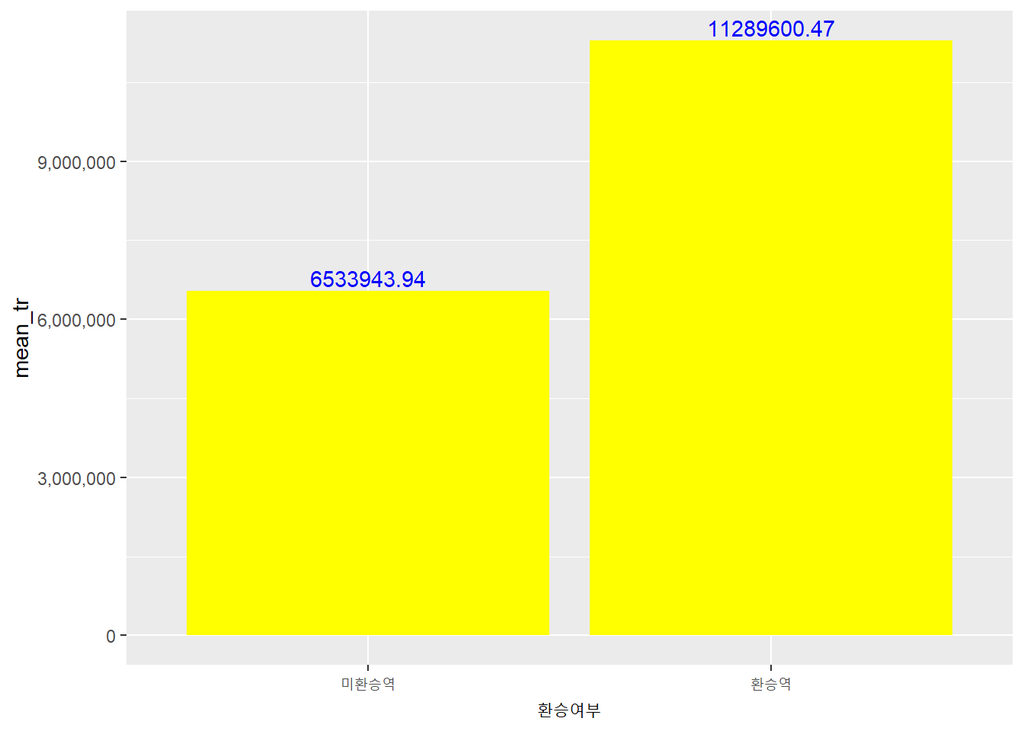

```r
ggplot(subway_tr, aes(환승여부, mean_tr)) + geom_col(fill="yellow")  + scale_y_continuous(labels = scales::comma) + geom_text(aes(y=mean_tr,label=mean_tr),col="blue", vjust=-0.3)
```

```r
shapiro.test(subway_tr2$mean_i[subway_tr2$환승여부=="미환승역"])
```

```
##
##  Shapiro-Wilk normality test
##
## data:  subway_tr2$mean_i[subway_tr2$환승여부 == "미환승역"]
## W = 0.38787, p-value < 2.2e-16
```

```r
shapiro.test(subway_tr2$mean_i[subway_tr2$환승여부=="환승역"])
```

```
##
##  Shapiro-Wilk normality test
##
## data:  subway_tr2$mean_i[subway_tr2$환승여부 == "환승역"]
## W = 0.29778, p-value < 2.2e-16
```

```r
var.test(mean_i~환승여부, data=subway_tr2)
```

```
##
##  F test to compare two variances
##
## data:  mean_i by 환승여부
## F = 0.075122, num df = 167, denom df = 72, p-value < 2.2e-16
## alternative hypothesis: true ratio of variances is not equal to 1
## 95 percent confidence interval:
##  0.04991504 0.10960130
## sample estimates:
## ratio of variances
##         0.07512244
```

```r
t.test(mean_i~환승여부, data=subway_tr2, var.test=T, alt="two.sided")
```

```
##
##  Welch Two Sample t-test
##
## data:  mean_i by 환승여부
## t = -1.4249, df = 76.742, p-value = 0.1583
## alternative hypothesis: true difference in means is not equal to 0
## 95 percent confidence interval:
##  -11402085   1890772
## sample estimates:
## mean in group 미환승역   mean in group 환승역
##                6533944               11289600
```

2-10. 공기질이 안좋은 곳은 임대료가 낮을까?

```r
View(air)
air_passenger_max <- passenger_join %>% filter(mean_i != 0) %>% mutate(passenger_rent = round(mean_i/일평균),0) %>% arrange(desc(passenger_rent)) %>% select(역명, mean_i, sum_i, 호선, 일평균, passenger_rent) %>% arrange(desc(passenger_rent))
View(air_passenger_max)
air_join <- inner_join(air_passenger_max, air)
View(air_join)

spm_de <- air_join %>% select(역명, passenger_rent, 일평균, SPM) %>% arrange(desc(SPM)) %>% head(10)
spm_de
```

```
## # A tibble: 10 x 4
##    역명     passenger_rent 일평균   SPM
##    <chr>             <dbl>  <dbl> <dbl>
##  1 장한평              147  33246  155.
##  2 내방                300  25755  149.
##  3 화랑대              202  18549  147
##  4 선릉                 77  93071  134.
##  5 복정_8              508  17525  130.
##  6 도곡                126   9533  130.
##  7 송정                211  12628  128.
##  8 마포구청            365  24362  124.
##  9 왕십리_5            339   9101  123.
## 10 오목교              278  43191  120.
```

```r
CO2_de <- air_join %>% select(역명, passenger_rent, 일평균, CO2) %>% arrange(desc(CO2)) %>% head(10)
CO_de <- air_join %>% select(역명, passenger_rent, 일평균, CO) %>% arrange(desc(CO)) %>% head(10)
HCHO_de <- air_join %>% select(역명, passenger_rent, 일평균, HCHO) %>% arrange(desc(HCHO)) %>% head(10)



#SPM.미세먼지 (기준치 140㎍/㎥)
#CO2.이산화탄소 (기준치 1000ppm)
#CO.일산화탄소 (기준치 9ppm)
#HCHO.포름알데히드 (기준치 100ppm)
```

```r
#SPM
spm_de <- air_join %>% select(역명, passenger_rent, 일평균, SPM) %>% arrange(desc(passenger_rent)) %>% head(10)
spm_de
```

```
## # A tibble: 10 x 4
##    역명           passenger_rent 일평균   SPM
##    <chr>                   <dbl>  <dbl> <dbl>
##  1 약수_6                   1584   6669  65.6
##  2 영등포구청_5             1236   7493  54.7
##  3 부천종합운동장           1150   7853  47.4
##  4 신길_5                   1124   6957  58.6
##  5 녹사평                    938   9266  35.4
##  6 삼산체육관                932   8206  74.8
##  7 올림픽공원_5              834   6995  48
##  8 건대입구_7                787  24802  52.2
##  9 신중동                    786  25943  66.9
## 10 안암                      786  18656  56.9
```

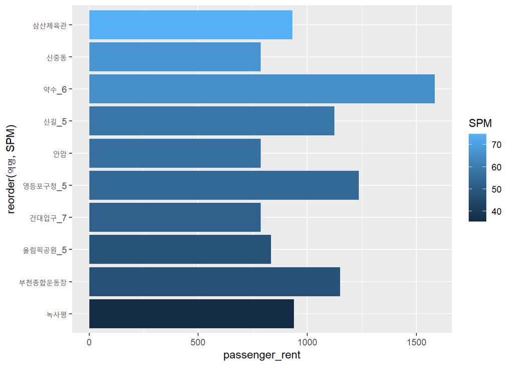

```r
ggplot(spm_de, aes(reorder(역명, SPM), passenger_rent, fill=SPM)) + geom_col() + coord_flip()
```

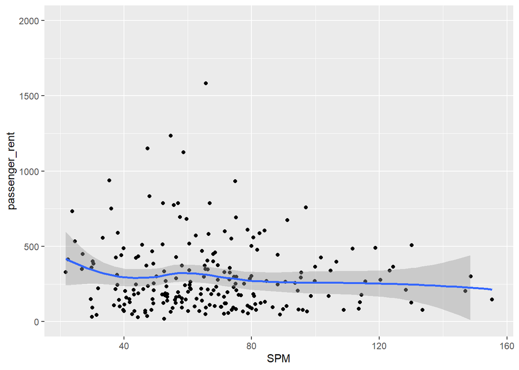

```r
spm_de1 <- air_join %>% select(역명, passenger_rent, 일평균, SPM) %>% arrange(desc(passenger_rent))
ggplot(data=spm_de1, aes(x=SPM, y=passenger_rent)) + geom_point() + stat_smooth() + ylim(0,2000)
```

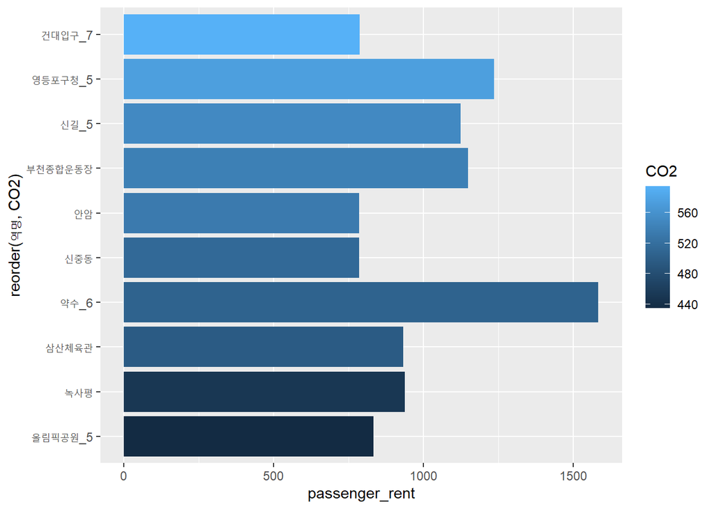

```r
CO2_de <- air_join %>% select(역명, passenger_rent, 일평균, CO2) %>% arrange(desc(passenger_rent)) %>% head(10)
ggplot(CO2_de, aes(reorder(역명, CO2), passenger_rent, fill=CO2)) + geom_col() + coord_flip()
```

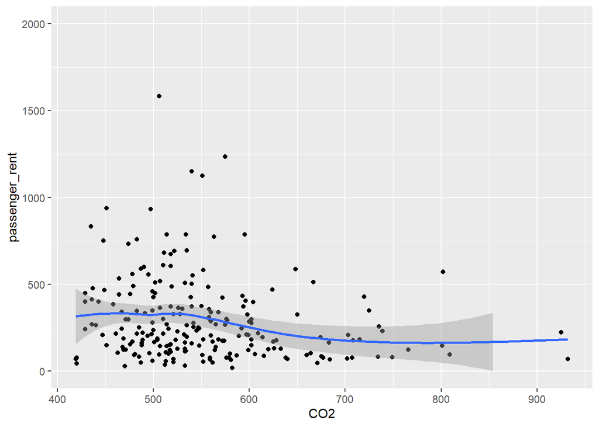

```r
CO2_de1 <- air_join %>% select(역명, passenger_rent, 일평균, CO2) %>% arrange(desc(passenger_rent))
ggplot(data=CO2_de1, aes(x=CO2, y=passenger_rent)) + geom_point() + stat_smooth() + ylim(0,2000)
```